# Step 1 - Prepare input data

This Python script will download the required input data and prepare it for the analysis. After this, run "Step 2 - Network analysis.ipynb" to generate the travel time matrices, then "Step 3 - Final analysis.ipynb" to complete the analysis and generate the visualizations.

```python
import requests
import pandas as pd
import geopandas as gpd
import numpy as np
import os
import shutil
```

## Create regional county boundaries dataset

Download Shapefile containing county boundaries for all US states from the census bureau.

```python
fileDir = os.path.normpath("./input_data/counties/")
zip_filepath = os.path.join(os.path.join(fileDir, "temp.zip"))
if not os.path.exists(fileDir):
    os.makedirs(fileDir)

r = requests.get("https://www2.census.gov/geo/tiger/GENZ2021/shp/cb_2021_us_county_500k.zip", stream=True)
with open(zip_filepath, 'wb') as f:
    for chunk in r.iter_content(chunk_size=128):
        f.write(chunk)

shutil.unpack_archive(zip_filepath, os.path.dirname(zip_filepath))

os.unlink(zip_filepath)
```

Read in the county data, extract only the counties in the Central Ohio region. Write the regional counties to a new file.

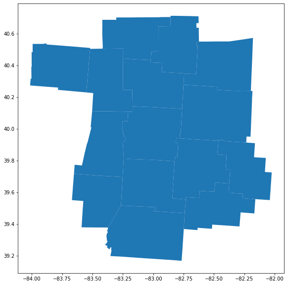

```python
COUNTY_LIST = {
    "Delaware":"041",
    "Fairfield":"045",
    "Fayette":"047",
    "Franklin":"049",
    "Hocking":"073",
    "Knox":"083",
    "Licking":"089",
    "Logan":"091",
    "Madison":"097",
    "Marion":"101",
    "Morrow":"117",
    "Perry":"127",
    "Pickaway":"129",
    "Ross":"141",
    "Union":"159"
}

counties_all = gpd.read_file(os.path.join(fileDir, "cb_2021_us_county_500k.shp"))
counties_region = counties_all.loc[(counties_all["STATE_NAME"] == "Ohio") & (counties_all["COUNTYFP"].isin(COUNTY_LIST.values()))]
counties_region = counties_region.to_crs(epsg=4326)
counties_region.to_file("./temp_data/counties.shp")
ax = counties_region.plot(figsize=(10,10))
```

## Create region boundary dataset

Dissolve the regional counties to get the boundary for the entire region.

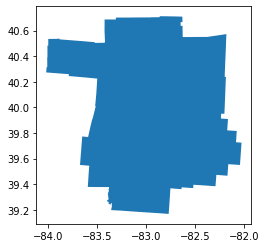

```python
region = counties_region.dissolve()
region.to_file("./temp_data/region.shp")
region.plot()
```

## Create tract boundaries and centroids datasets

Download Shapefile containing census tract boundaries for Ohio tracts from the census bureau.

```python
fileDir = os.path.normpath("./input_data/tracts/")
zip_filepath = os.path.join(os.path.join(fileDir, "temp.zip"))
if not os.path.exists(fileDir):
    os.makedirs(fileDir)

r = requests.get("https://www2.census.gov/geo/tiger/TIGER2021/TRACT/tl_2021_39_tract.zip", stream=True)
with open(zip_filepath, 'wb') as f:
    for chunk in r.iter_content(chunk_size=128):
        f.write(chunk)

shutil.unpack_archive(zip_filepath, os.path.dirname(zip_filepath))

os.unlink(zip_filepath)
```

Read in the tract data and extract only the tracts that fall within the region. Write the regional tracts to a new file.

```python
tracts_all = gpd.read_file("./input_data/tracts/tl_2021_39_tract.shp", dtype=object)
tracts_region = tracts_all.loc[(tracts_all["STATEFP"] == '39') & (tracts_all["COUNTYFP"].isin(COUNTY_LIST.values()))]
tracts_region = tracts_region \
    .filter(axis="columns", items=["GEOID", "COUNTYFP", "geometry"]) \
    .to_crs(epsg=4326)
tracts_region.to_file("./temp_data/tracts.shp")
```

Create a feature class of the tract centroids. Note that in a later step these will be snapped to the OSM street network.

```python
centroids = tracts_region.to_crs(epsg=3735).centroid.to_crs(epsg=4326)

tract_centroids = gpd.GeoDataFrame(data=tracts_region.drop(columns=["geometry"]), geometry=centroids)

tract_centroids.to_file("./temp_data/tract_points_raw.shp")
```

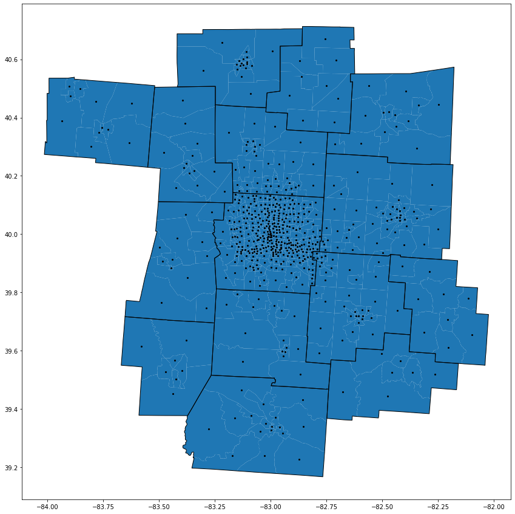

```python
ax = tracts_region.plot(figsize=(15,15))
tract_centroids.plot(ax=ax, color="black", markersize=4)
counties_region.plot(ax=ax, edgecolor="black", facecolor="none")
```

## Download census population data

Download Shapefile containing census block boundaries for Ohio blocks from the census bureau.

```python
fileDir = os.path.normpath("./input_data/blocks/")
zip_filepath = os.path.join(os.path.join(fileDir, "temp.zip"))
if not os.path.exists(fileDir):
    os.makedirs(fileDir)

r = requests.get("https://www2.census.gov/geo/tiger/TIGER2021/TABBLOCK20/tl_2021_39_tabblock20.zip", stream=True)
with open(zip_filepath, 'wb') as f:
    for chunk in r.iter_content(chunk_size=128):
        f.write(chunk)

shutil.unpack_archive(zip_filepath, os.path.dirname(zip_filepath))

os.unlink(zip_filepath)
```

Read in the block data and extract only the blocks that fall within the region.

```python
blocks_raw = gpd.read_file("./input_data/blocks/tl_2021_39_tabblock20.shp", dtype="object")

blocks = blocks_raw.copy()

blocks = blocks.loc[blocks["COUNTYFP20"].isin(COUNTY_LIST.values())]
blocks = blocks \
    .rename(columns={
        "COUNTYFP20":"COUNTYFP",
        "GEOID20":"GEOID"
    }) \
    .filter(axis="columns", items=["GEOID", "COUNTYFP", "geometry"])
```

Download the 2020 decennial census population for each block from the Census API, remove the prefix from the GEOID, and rename the fields to more convenient names.

```python
r = requests.get("https://api.census.gov/data/2020/dec/pl?get=GEO_ID,P1_001N&for=block:*&in=state:39%20county:{}".format(",".join(COUNTY_LIST.values())))
records = r.json()
columns = records.pop(0)
blockData = pd.DataFrame.from_records(records, columns=columns)

blockData["GEOID"] = blockData["GEO_ID"].apply(lambda x:x.split("US")[1])
blockData = blockData \
    .rename(columns={
        "county":"COUNTYFP",
        "P1_001N":"TOTALPOP"
    }) \
    .filter(axis="columns", items=["GEOID", "COUNTYFP", "TOTALPOP"])
```

Join the population data to the blocks feature class and write it to a Shapefile.

```python
blocks = blocks \
    .merge(blockData, left_on="GEOID", right_on="GEOID") \
    .filter(axis="columns", items=["GEOID","COUNTYFP_x", "TOTALPOP", "geometry"]) \
    .rename(columns={"COUNTYFP_x":"COUNTYFP"})
blocks.to_file("./temp_data/blocks.shp")
blocks.head()
```

|  | GEOID | COUNTYFP | TOTALPOP | geometry |
| --- | --- | --- | --- | --- |
| 0 | 390970412003030 | 097 | 27 | POLYGON ((-83.27196 39.71246, -83.27196 39.712... |
| 1 | 390970412003005 | 097 | 94 | POLYGON ((-83.28681 39.71786, -83.28154 39.719... |
| 2 | 390970412002014 | 097 | 0 | POLYGON ((-83.25954 39.71574, -83.25571 39.718... |
| 3 | 390970411004019 | 097 | 1 | POLYGON ((-83.39468 39.89435, -83.39383 39.894... |
| 4 | 390970413001057 | 097 | 1 | POLYGON ((-83.59370 39.76228, -83.59240 39.762... |

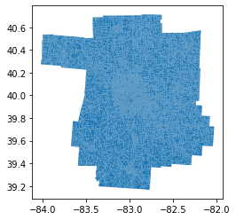

```python
blocks.plot()
```

## Create a rectangular grid of destination points

This will create a dense grid of points that fills the bounding box for the region. It will be used later to compute a travel time surface, which will ultimately be converted to isochrones. Note that these points will be snapped to the OSM street network in a later step.

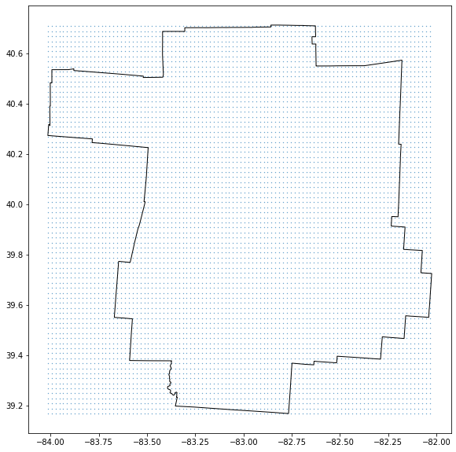

```python
GRIDSPACING = 0.02

bounds = region.total_bounds

xmin = bounds[0]
xmax = bounds[2]
ymin = bounds[1]
ymax = bounds[3]

x = np.arange(xmin, xmax, GRIDSPACING)

y = np.arange(ymin, ymax, GRIDSPACING)

X,Y = np.meshgrid(x,y)

points = gpd.GeoDataFrame(geometry=gpd.points_from_xy(X.ravel(), Y.ravel()))
points = points.reset_index().rename(columns={"index":"id"})

points.to_file("./temp_data/points_raw.shp")

ax = points.plot(markersize=0.1, figsize=(10,10))
region.plot(ax=ax, edgecolor="black", facecolor="none")
```

## Download OpenStreetMap extract

The following block will download the OpenStreetMap extract for the State of Ohio. For other available extracts, see https://www.geofabrik.de/data/download.html.

```python
fileDir = os.path.normpath("./input_data/")
if not os.path.exists(fileDir):
    os.makedirs(fileDir)

r = requests.get("https://download.geofabrik.de/north-america/us/ohio-latest.osm.pbf", stream=True)
with open(os.path.join(fileDir, "ohio-latest.osm.pbf"), 'wb') as f:
    for chunk in r.iter_content(chunk_size=128):
        f.write(chunk)
```

## Download GTFS data

The following block will download the GTFS data for the Central Ohio Transit Authority. To obtain GTFS data from other agencies, see https://database.mobilitydata.org/.

```python
fileDir = os.path.normpath("./input_data/")
if not os.path.exists(fileDir):
    os.makedirs(fileDir)

r = requests.get("https://www.cota.com/data/cota.gtfs.zip", stream=True)
with open(os.path.join(fileDir, "cota.gtfs.zip"), 'wb') as f:
    for chunk in r.iter_content(chunk_size=128):
        f.write(chunk)
```

## Create origin shapefiles

Create a Shapefile consisting of a single point at the approximate location of the Intel plant.

```python
site = gpd.read_file("./input_data/site/site.geojson")
site["id"] = site["id"].astype("int")
site = site.to_crs(epsg=4326)
site.to_file("./input_data/site/site.shp")
site.head()
```

|  | id | geometry |
| --- | --- | --- |
| 0 | 0 | POINT (-82.71037 40.11924) |

Create a Shapefile consisting of a single point at the approximate location of the COTA Park & Ride near the Intel plant.

```python
park_and_ride = gpd.read_file("./input_data/park_and_ride/park_and_ride.geojson")
park_and_ride["id"] = park_and_ride["id"].astype("int")
park_and_ride = park_and_ride.to_crs(epsg=4326)
park_and_ride.to_file("./input_data/park_and_ride/park_and_ride.shp")
park_and_ride.head()
```

|  | id | geometry |
| --- | --- | --- |
| 0 | 0 | POINT (-82.78828 40.09070) |

Create a Shapefile containing the tract centroid nearest to the Ohio GIS Conference location.

```python
conference_location = tract_centroids.loc[tract_centroids["GEOID"] == "39049007820"].copy()
conference_location = conference_location.rename(columns={"GEOID":"id"})
conference_location.to_file("./temp_data/conference_location.shp")
```

Plot the points on a map to show the context. Red point is the Intel site. Pink point is the park and ride. Blue point is the approximate location of the Ohio GIS conference.

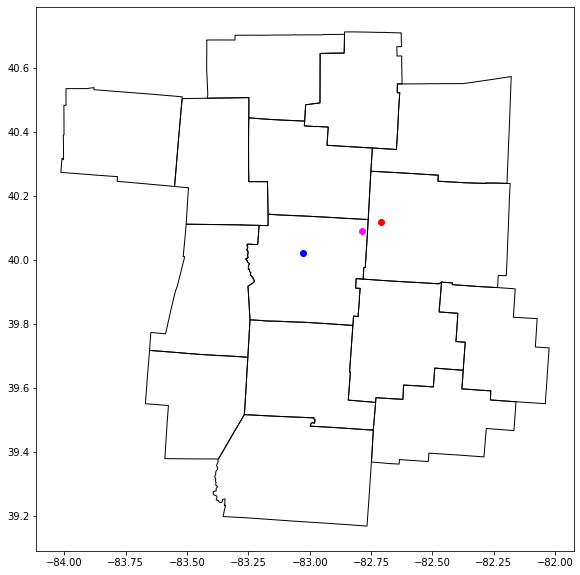

```python
ax = site.plot(markersize=36, color="red", figsize=(10,10))
park_and_ride.plot(ax=ax, markersize=36, color="#fc0cf4")
conference_location.plot(ax=ax, markersize=36, color="blue")
counties_region.plot(ax=ax, edgecolor="black", facecolor="none")
```